# Certification exam, Form A: Technical report

Psychometrics team (fictional example) | November 03, 2026 | mirt 1.47 | mirtverse 0.2.0

## Summary

### Overview

- A 2PL model with 1 dimension was fitted to 1200 respondents and 31 items (EM estimation).
- The estimation converged normally.

### Model fit

- Overall model fit is close: M2 = 561.36, df = 434, RMSEA = 0.016, CFI = 0.987, SRMSR = 0.030.
- The chi-square test is significant, but with large samples this is common; the RMSEA indicates the misfit is small in practical terms.

### Reliability

- Marginal reliability is 0.83 (good).

### Targeting

- The average item location is -0.18 and the average person score is -0.00, so the test is well targeted for this group.
- Measurement is most precise around theta = -0.52 (information = 6.04, SE = 0.41).

### Items

- Low discrimination: Q12 (a = 0.42), Q30 (a = 0.43), Q32 (a = 0.47). These items barely separate high and low scorers; review the key and wording.
- Extreme location: Q32 (b = 3.05). These items are far too easy or too hard for most respondents.
- Low item-total correlation: Q12 (r = 0.16), Q21 (r = 0.19), Q30 (r = 0.19), Q32 (r = 0.17). These items relate weakly to the rest of the test.
- Misfit: Q04 (S-X2 p = .004), Q12 (S-X2 p = .002), Q17 (S-X2 p = .002). The model does not describe responses to these items well (alpha = 0.01); inspect them with gg_empirical() or item_card().

### Local dependence

- 1 item pair shows possible local dependence (Q3 exceeds the average of -0.03 by more than 0.2).
- Strongest: Q21 & Q22 (Q3 = 0.27).
- Check whether these items share a stimulus, wording, or content; consider a testlet or bifactor model.

### Person fit

- 1.8% of respondents have unusual response patterns (Zh < -1.96), which is within what chance alone would produce.

## Model

| Statistic | Value |
| --- | --- |
| nobs | 1200 |
| nitems | 31 |
| nfact | 1 |
| itemtype | 2PL |
| npar | 62 |
| logLik | -20593.4 |
| AIC | 41310.7 |
| BIC | 41626.3 |
| SABIC | 41429.4 |
| converged | yes |
| method | EM |
| fit_stat | M2 |
| M2 | 561.4 |
| df | 434 |
| p.value | 0.000 |
| RMSEA | 0.016 |
| SRMSR | 0.030 |
| CFI | 0.987 |
| TLI | 0.986 |
| reliability | 0.831 |

## Items

Status uses the item health rules: red for misfit or low discrimination, amber for other flags, green otherwise.

| item | status | itemtype | N | mean | item_total_r | S_X2 | df | RMSEA | p.value | flag |
| --- | --- | --- | --- | --- | --- | --- | --- | --- | --- | --- |
| Q01 | green | 2PL | 1200 | 0.365 | 0.319 | 14.433 | 22 | 0 | 0.885 |  |
| Q02 | green | 2PL | 1200 | 0.567 | 0.375 | 25.562 | 21 | 0.013 | 0.224 |  |
| Q03 | green | 2PL | 1200 | 0.312 | 0.377 | 22.891 | 21 | 0.009 | 0.350 |  |
| Q04 | red | 2PL | 1200 | 0.338 | 0.311 | 43.356 | 22 | 0.028 | 0.004 | misfit |
| Q05 | green | 2PL | 1200 | 0.629 | 0.360 | 20.135 | 20 | 0.002 | 0.450 |  |
| Q06 | green | 2PL | 1200 | 0.266 | 0.301 | 34.593 | 21 | 0.023 | 0.031 |  |
| Q07 | green | 2PL | 1200 | 0.747 | 0.316 | 23.277 | 20 | 0.012 | 0.275 |  |
| Q08 | green | 2PL | 1200 | 0.347 | 0.296 | 16.305 | 22 | 0 | 0.800 |  |
| Q09 | green | 2PL | 1200 | 0.795 | 0.209 | 28.219 | 22 | 0.015 | 0.169 |  |
| Q10 | green | 2PL | 1200 | 0.499 | 0.300 | 31.586 | 22 | 0.019 | 0.085 |  |
| Q11 | green | 2PL | 1200 | 0.917 | 0.281 | 21.980 | 16 | 0.018 | 0.144 |  |
| Q12 | red | 2PL | 1200 | 0.263 | 0.157 | 46.575 | 22 | 0.031 | 0.002 | low discrimination; low item-total correlation; misfit |
| Q13 | green | 2PL | 1200 | 0.665 | 0.361 | 30.598 | 20 | 0.021 | 0.061 |  |
| Q15 | green | 2PL | 1200 | 0.759 | 0.289 | 26.694 | 21 | 0.015 | 0.181 |  |
| Q16 | green | 2PL | 1200 | 0.369 | 0.342 | 30.285 | 22 | 0.018 | 0.112 |  |
| Q17 | red | 2PL | 1200 | 0.921 | 0.233 | 38.053 | 17 | 0.032 | 0.002 | misfit |
| Q18 | green | 2PL | 1200 | 0.398 | 0.484 | 32.216 | 20 | 0.023 | 0.041 |  |
| Q19 | green | 2PL | 1200 | 0.484 | 0.336 | 15.923 | 21 | 0 | 0.774 |  |
| Q20 | green | 2PL | 1200 | 0.690 | 0.436 | 24.100 | 18 | 0.017 | 0.152 |  |
| Q21 | amber | 2PL | 1200 | 0.769 | 0.191 | 23.694 | 23 | 0.005 | 0.421 | low item-total correlation |
| Q22 | green | 2PL | 1200 | 0.815 | 0.244 | 16.518 | 21 | 0 | 0.740 |  |
| Q23 | green | 2PL | 1200 | 0.341 | 0.281 | 16.358 | 22 | 0 | 0.798 |  |
| Q24 | green | 2PL | 1200 | 0.632 | 0.393 | 17.984 | 20 | 0 | 0.588 |  |
| Q25 | green | 2PL | 1200 | 0.390 | 0.303 | 22.183 | 22 | 0.003 | 0.449 |  |
| Q26 | green | 2PL | 1200 | 0.427 | 0.482 | 24.095 | 19 | 0.015 | 0.193 |  |
| Q27 | green | 2PL | 1200 | 0.752 | 0.292 | 16.813 | 21 | 0 | 0.722 |  |
| Q28 | green | 2PL | 1200 | 0.549 | 0.331 | 17.983 | 21 | 0 | 0.650 |  |
| Q29 | green | 2PL | 1200 | 0.318 | 0.373 | 26.799 | 21 | 0.015 | 0.178 |  |
| Q30 | red | 2PL | 1200 | 0.532 | 0.186 | 35.340 | 23 | 0.021 | 0.048 | low discrimination; low item-total correlation |
| Q31 | green | 2PL | 1200 | 0.767 | 0.410 | 11.500 | 17 | 0 | 0.829 |  |
| Q32 | red | 2PL | 1200 | 0.203 | 0.167 | 20.112 | 23 | 0 | 0.635 | low discrimination; extreme location; low item-total correlation |

### Item parameters

Parameterization: IRT (a, b, g, u).

| item | a | b |
| --- | --- | --- |
| Q01 | 0.833 | 0.750 |
| Q02 | 1.039 | -0.335 |
| Q03 | 1.036 | 0.909 |
| Q04 | 0.770 | 0.978 |
| Q05 | 1.059 | -0.630 |
| Q06 | 0.813 | 1.413 |
| Q07 | 0.998 | -1.301 |
| Q08 | 0.761 | 0.926 |
| Q09 | 0.650 | -2.266 |
| Q10 | 0.749 | -0.008 |
| Q11 | 1.573 | -2.046 |
| Q12 | 0.416 | 2.568 |
| Q13 | 1.085 | -0.796 |
| Q15 | 0.901 | -1.485 |
| Q16 | 0.918 | 0.671 |
| Q17 | 1.273 | -2.373 |
| Q18 | 1.492 | 0.357 |
| Q19 | 0.883 | 0.067 |
| Q20 | 1.576 | -0.748 |
| Q21 | 0.542 | -2.359 |
| Q22 | 0.790 | -2.103 |
| Q23 | 0.709 | 1.023 |
| Q24 | 1.209 | -0.597 |
| Q25 | 0.793 | 0.628 |
| Q26 | 1.519 | 0.240 |
| Q27 | 0.914 | -1.419 |
| Q28 | 0.886 | -0.277 |
| Q29 | 1.014 | 0.896 |
| Q30 | 0.425 | -0.324 |
| Q31 | 1.652 | -1.059 |
| Q32 | 0.471 | 3.047 |

## Graphics

### Test information

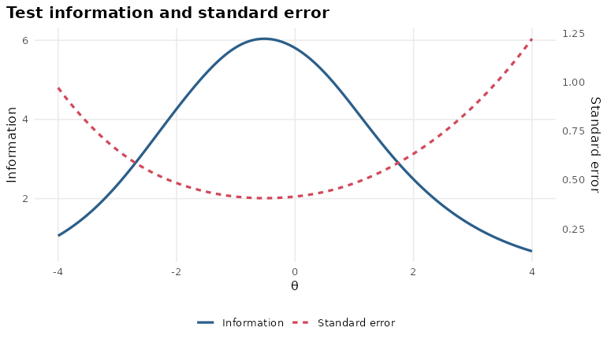

### Wright map

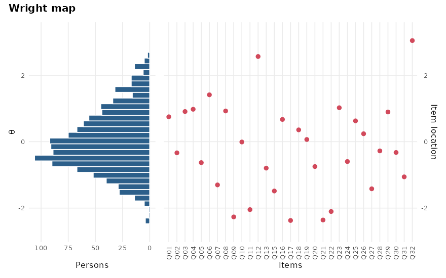

### Item characteristic curves

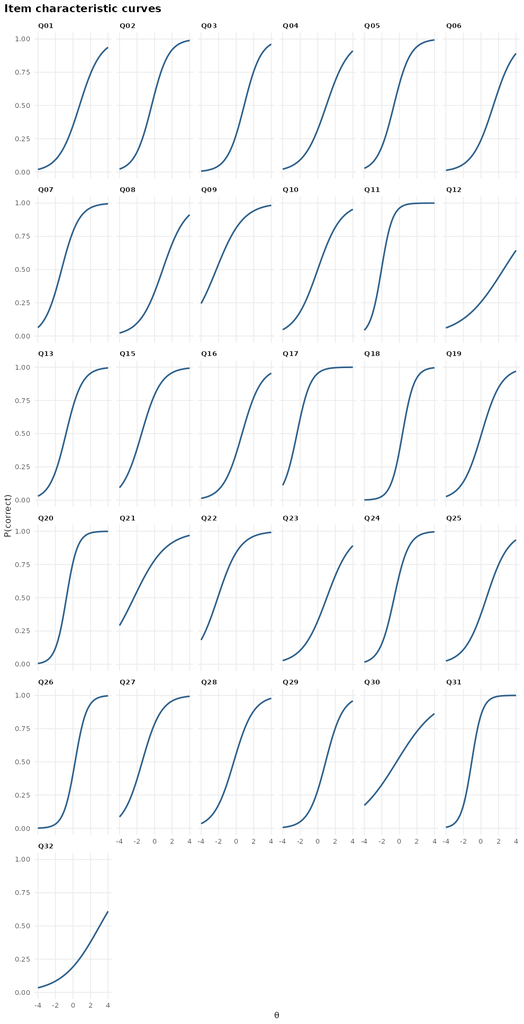

### Item fit

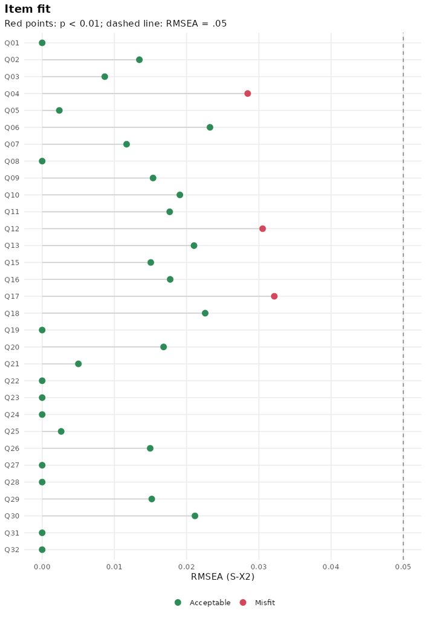

### Local dependence

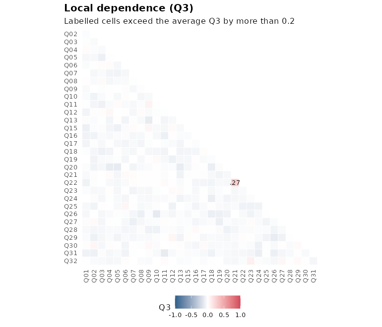

## Scores

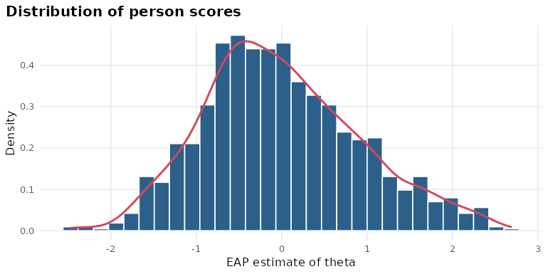

### Sum score conversion table

Expected a posteriori (EAP) ability for each total score, with its standard error. Observed and expected counts show how well the model reproduces the score distribution.

| Sum.Scores | F1 | SE_F1 | observed | expected |
| --- | --- | --- | --- | --- |
| 0 | -3.073 | 0.557 | 0 | 0.136 |
| 1 | -2.824 | 0.532 | 0 | 0.670 |
| 2 | -2.586 | 0.509 | 1 | 1.868 |
| 3 | -2.362 | 0.489 | 1 | 3.927 |
| 4 | -2.151 | 0.470 | 2 | 6.956 |
| 5 | -1.952 | 0.455 | 4 | 10.980 |
| 6 | -1.763 | 0.441 | 11 | 15.943 |
| 7 | -1.583 | 0.430 | 19 | 21.725 |
| 8 | -1.410 | 0.421 | 25 | 28.154 |
| 9 | -1.243 | 0.414 | 41 | 35.027 |
| 10 | -1.081 | 0.408 | 33 | 42.125 |
| 11 | -0.923 | 0.404 | 61 | 49.223 |
| 12 | -0.767 | 0.401 | 70 | 56.084 |
| 13 | -0.614 | 0.400 | 90 | 62.465 |
| 14 | -0.462 | 0.399 | 94 | 68.117 |
| 15 | -0.310 | 0.400 | 69 | 72.792 |
| 16 | -0.159 | 0.402 | 85 | 76.263 |
| 17 | -0.006 | 0.405 | 82 | 78.328 |
| 18 | 0.149 | 0.410 | 76 | 78.831 |
| 19 | 0.306 | 0.416 | 68 | 77.660 |
| 20 | 0.466 | 0.423 | 59 | 74.756 |
| 21 | 0.631 | 0.432 | 64 | 70.121 |
| 22 | 0.801 | 0.442 | 45 | 63.826 |
| 23 | 0.976 | 0.454 | 40 | 56.040 |
| 24 | 1.159 | 0.468 | 46 | 47.062 |
| 25 | 1.350 | 0.484 | 21 | 37.350 |
| 26 | 1.550 | 0.503 | 30 | 27.532 |
| 27 | 1.760 | 0.523 | 21 | 18.369 |
| 28 | 1.981 | 0.545 | 19 | 10.654 |
| 29 | 2.212 | 0.569 | 17 | 5.021 |
| 30 | 2.451 | 0.593 | 5 | 1.693 |
| 31 | 2.692 | 0.615 | 1 | 0.301 |

## Item health cards

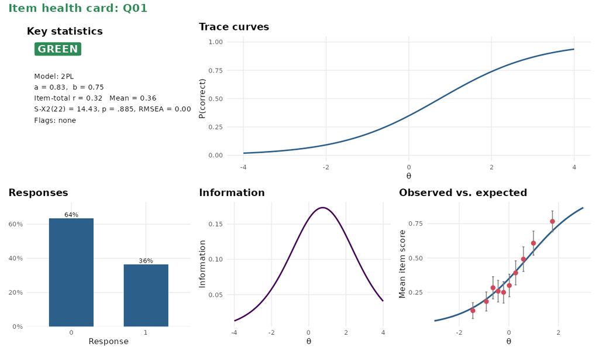

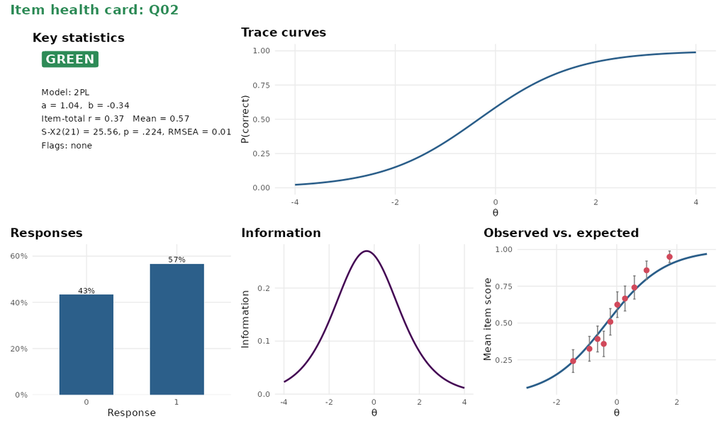

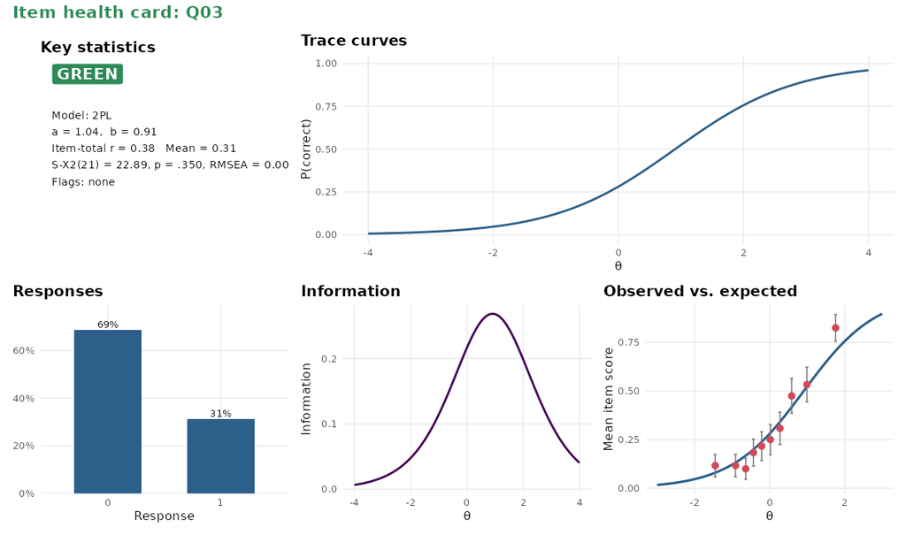

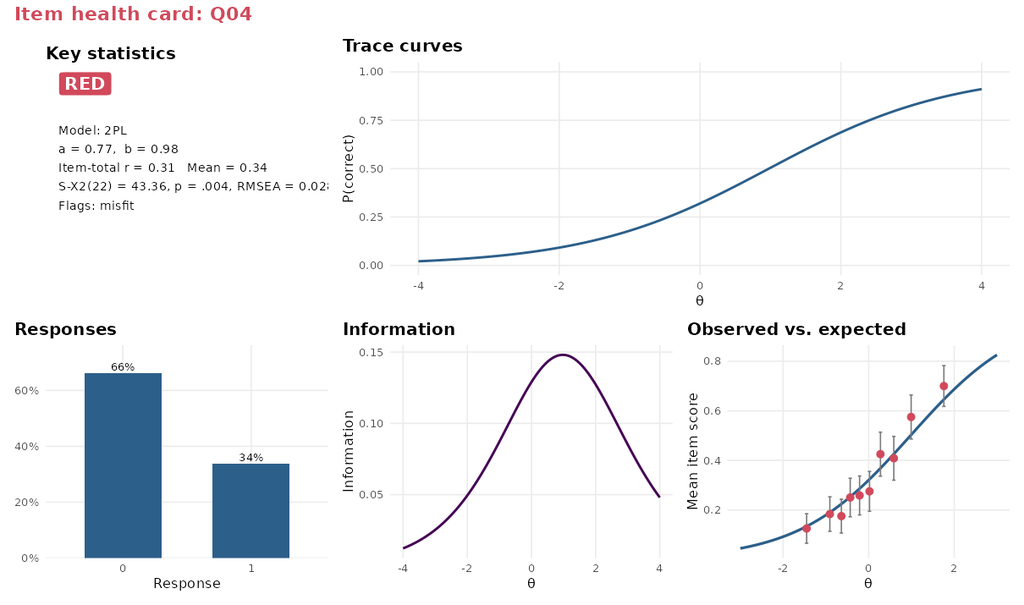

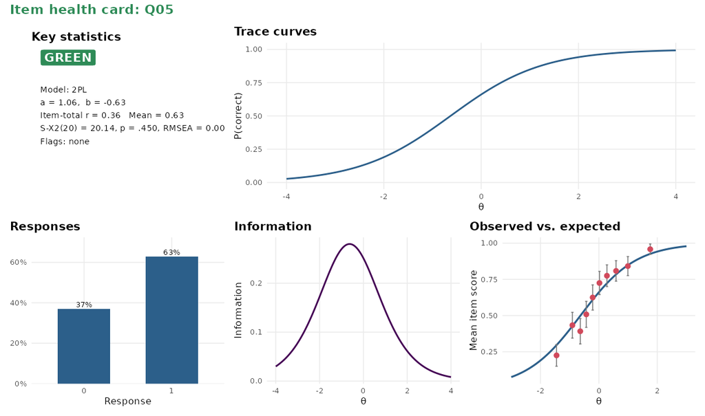

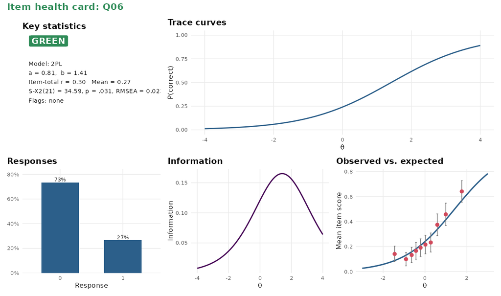

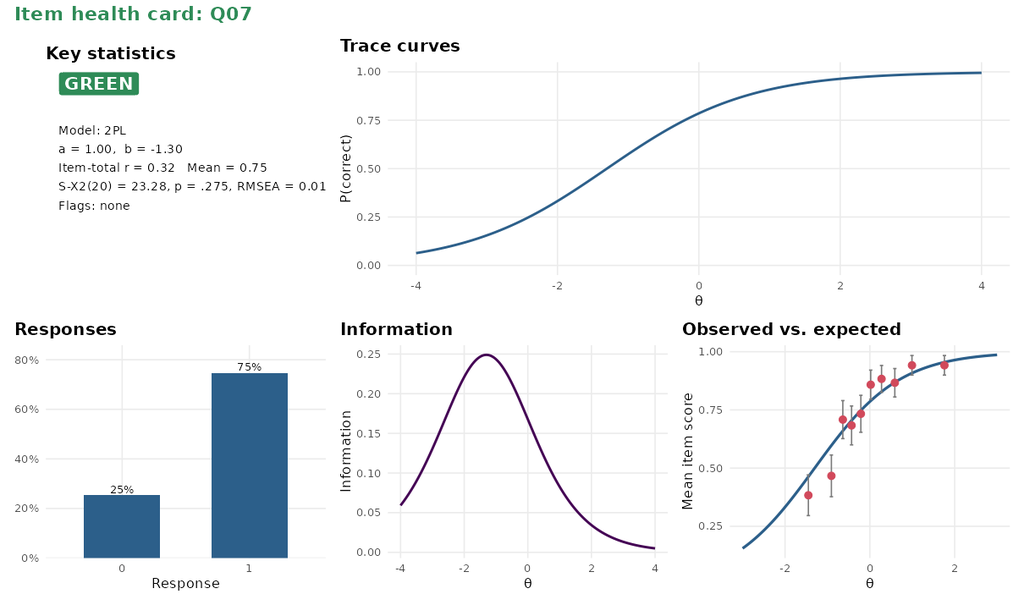

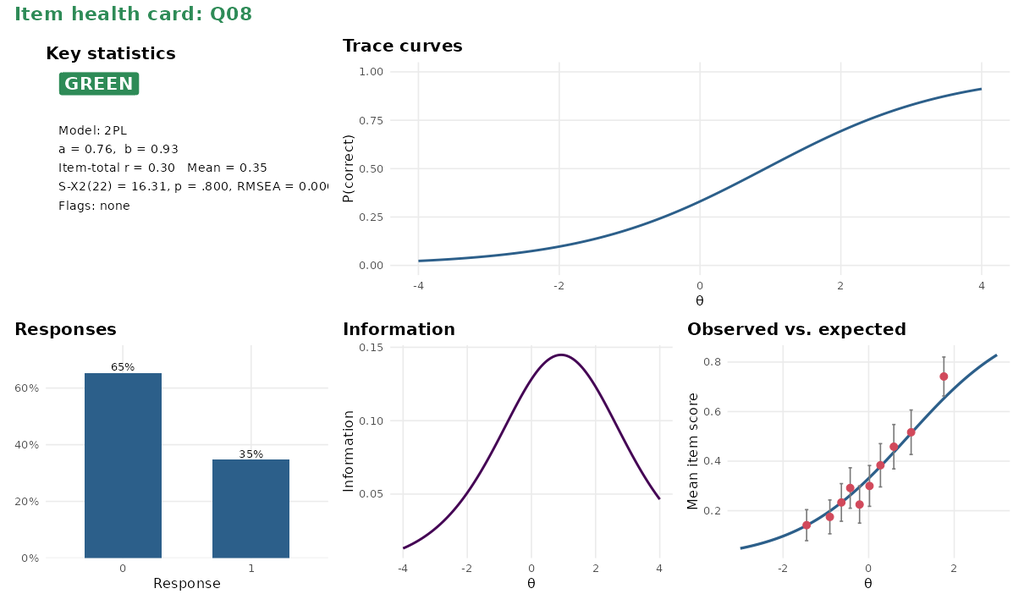

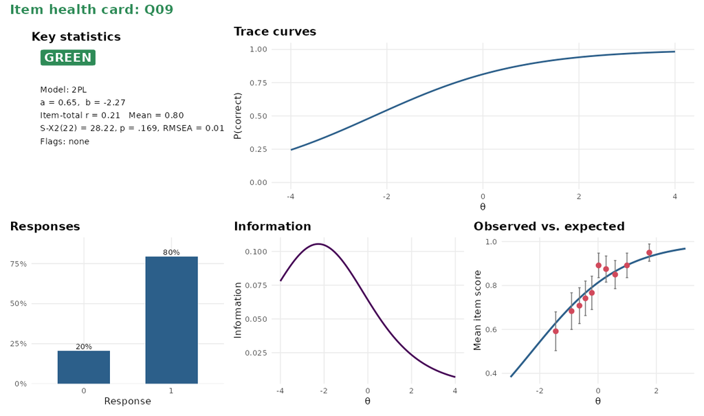

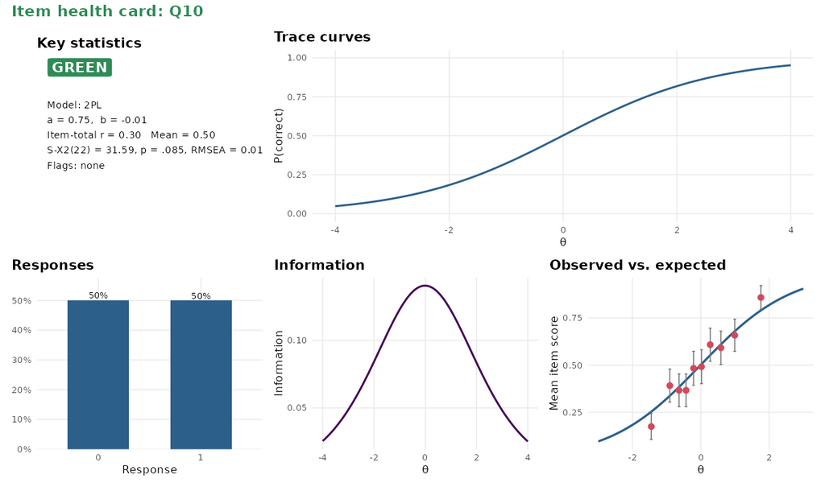

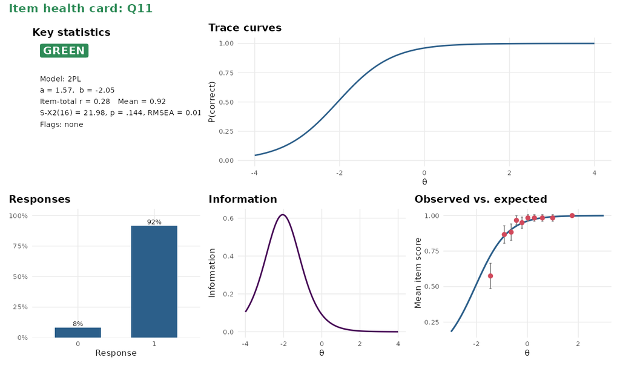

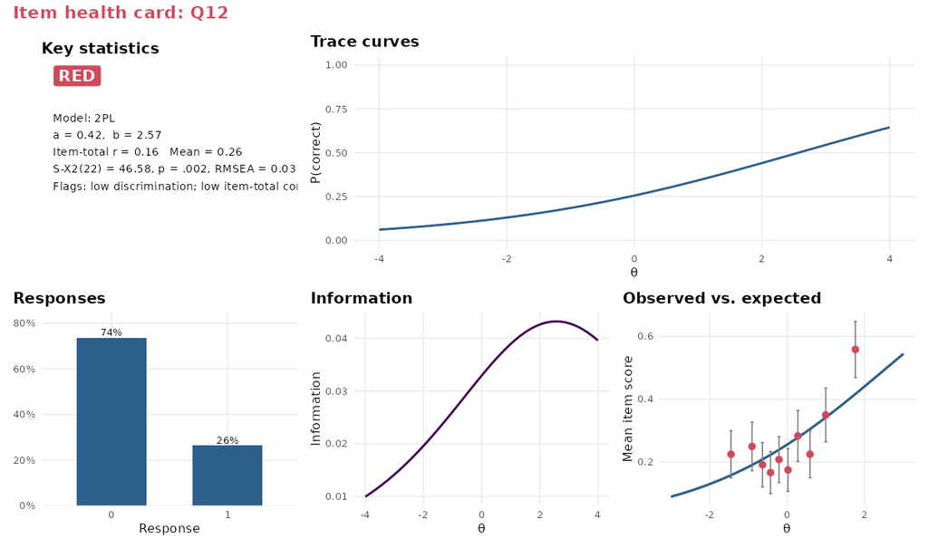

[19 more figures not shown]

## Blueprint

Construct: Professional knowledge for certification. Test takers: not stated. Score use: pass/fail certification. Forms have 12 items (multiple choice); target reliability 0.85.

| content | cognitive | n |
| --- | --- | --- |
| Ethics | NA | 4 |
| Practice | NA | 5 |
| Law | NA | 3 |

## Field-test design

The field test uses 2 form(s) of 18 items, each taken by 600 test takers, with 4 anchor items on every form, for calibration with the 2PL model.

In 2 simulated field tests the slopes were recovered with an RMSE of 0.22 and the intercepts with an RMSE of 0.12.

| form | role | item |
| --- | --- | --- |
| 1 | anchor | 4 |
| 2 | anchor | 4 |
| 1 | unique | 14 |
| 2 | unique | 14 |

## Groups

Ability estimates (EAP) by group, with the average standard error. Groups with fewer than 10 respondents are left out.

| group | n | mean_theta | sd_theta | mean_se |
| --- | --- | --- | --- | --- |
| English | 750 | 0.118 | 0.913 | 0.411 |
| French | 450 | -0.198 | 0.878 | 0.402 |

## Cut scores

1 cut score(s) on the summed-score scale divide test takers into Fail, Pass. Decision quality was estimated by the method of Lee (2010) for the calibrated test, over 1,200 abilities: classification accuracy 0.861, consistency 0.809 (kappa 0.61).

### Cuts

| cut | label | theta | raw | sem |
| --- | --- | --- | --- | --- |
| 1 | Pass | 0.157 | 18 | 0.421 |

### Decision quality by cut

| cut | label | accuracy | consistency | kappa | false_positive | false_negative |
| --- | --- | --- | --- | --- | --- | --- |
| 1 | Pass | 0.861 | 0.809 | 0.613 | 0.095 | 0.044 |

### Expected share in each category

| category | expected | true |
| --- | --- | --- |
| Fail | 0.555 | 0.606 |
| Pass | 0.445 | 0.394 |

## Scoring

Test takers were scored by EAP: mean ability -0.00 (SD 0.91), median standard error 0.39.

## Test security

Security checks run: preknowledge, answer copying. Security flags are evidence for an investigation, not proof of misconduct; individual test takers are not named in this report.

No test taker showed evidence.

## Pipeline decisions

Every stage ran its checks and raised flags for review. Flags only warned (strict = FALSE). 9 flag(s) were raised; 1 are still open and 8 were acknowledged, overridden or fixed.

### Stages

| stage | status | summary |
| --- | --- | --- |
| 0 Blueprint | done | 3 cells, 12 items per form |
| 1 Item generation | not run |  |
| 2 Item review | not run |  |
| 3 Field-test design | done | 2 forms of 18 items, 4 anchors, 1,200 test takers |
| 4 Data intake | done | 1,200 respondents, 32 items, scored with key |
| 5 Calibration | done | 2PL, converged, reliability 0.83 |
| 6 Linking and bank | done | 31 items added to the bank |
| 7 Forms | not run |  |
| 8 Cut scores | done | 1 cut, accuracy 0.86, consistency 0.81 |
| 9 Scoring | done | EAP scores for 1,200 test takers, reliability 0.83 |
| 10 Test security | done | 2 checks; 0 test takers with evidence |
| 11 Reporting | done | written to certification-technical-report.html |
| 12 Bank monitoring | not run |  |

### Flags

| id | level | stage | check | target | value | rule | status | note | advice |
| --- | --- | --- | --- | --- | --- | --- | --- | --- | --- |
| 2 | block | intake | possible_miskey | Q14 | p = 0.18, item-total r = -0.23 | p < 0.1 or item-total r < 0 | fixed | Item dropped: Key confirmed wrong by the item writer | Check the answer key and the item text; fix the key or drop the item. |
| 4 | block | calibration | dif_large | Q09 | MH D-DIF = -2.01, French vs English (favours English) | ETS category C | overridden | Translation reviewed; French version revised | Have a fairness panel review the item; drop or revise it unless the difference is construct-relevant. |
| 1 | review | field_test | recovery | design | RMSE of slopes = 0.22 | RMSE <= 0.2 | acknowledged | Sample fixed by the testing window | Parameters would be estimated imprecisely; increase the sample per form or reduce the number of forms. |
| 3 | review | calibration | local_dependence | Q21 & Q22 | Q3 = 0.27 | \|Q3\| > 0.2 | acknowledged | Q21 and Q22 share a case; keep them apart on forms | The items may share a stimulus or cue each other; review them together or treat them as a testlet. |
| 5 | review | calibration | dif_moderate | Q27 | MH D-DIF = -1.01, French vs English (favours English) | ETS category B | acknowledged | Sent to the bias panel | Review the item for content that may favour one group. |
| 6 | review | calibration | low_reliability | test | marginal reliability = 0.83 | reliability < 0.85 | acknowledged | Operational forms will be longer than the field test | Scores are less precise than planned; add items or report wider score bands. |
| 8 | review | cuts | cut_precision | cut 1 (Pass) | SEM = 0.42 at theta = 0.16 | SEM <= 0.35 | acknowledged | Add items near the cut to the operational forms | The test has little information at this cut; assemble forms targeted at it (assemble_forms(theta = cut)). |
| 9 | review | scoring | score_reliability | scores | empirical reliability = 0.83 | reliability >= 0.85 | acknowledged | Field-test scores are not reported to candidates | Scores are less precise than the target; report score bands and consider a longer test. |
| 7 | info | calibration | person_misfit | 22 respondents | 1.8% of respondents | Zh < -1.96 | open |  | About 2.5% are expected by chance; many more may point to guessing, cheating or careless responding. See p$persons. |

### Decision log

| time | action | detail |
| --- | --- | --- |
| 2026-11-03 05:21:32 | set blueprint | 3 cells; use: pass/fail certification |
| 2026-11-03 05:21:34 | design field test | 2 forms of 18 items, 4 anchors, 1,200 test takers |
| 2026-11-03 05:21:34 | acknowledge | acknowledged #1 recovery (design): Sample fixed by the testing window |
| 2026-11-03 05:21:34 | add responses | 1200 respondents, 32 items |
| 2026-11-03 05:21:34 | drop items | Q14: Key confirmed wrong by the item writer |
| 2026-11-03 05:21:37 | calibrate | 2PL |
| 2026-11-03 05:21:37 | acknowledge | acknowledged #3 local_dependence (Q21 & Q22): Q21 and Q22 share a case; keep them apart on forms |
| 2026-11-03 05:21:37 | override | overridden #4 dif_large (Q09): Translation reviewed; French version revised |
| 2026-11-03 05:21:37 | acknowledge | acknowledged #5 dif_moderate (Q27): Sent to the bias panel |
| 2026-11-03 05:21:37 | acknowledge | acknowledged #6 low_reliability (test): Operational forms will be longer than the field test |
| 2026-11-03 05:21:37 | bank items | 31 items added to Certification bank |
| 2026-11-03 05:21:37 | set cuts | raw cuts at 18 |
| 2026-11-03 05:21:37 | score persons | EAP |
| 2026-11-03 05:21:37 | acknowledge | acknowledged #8 cut_precision (cut 1 (Pass)): Add items near the cut to the operational forms |
| 2026-11-03 05:21:37 | acknowledge | acknowledged #9 score_reliability (scores): Field-test scores are not reported to candidates |
| 2026-11-03 05:21:39 | check security | preknowledge, answer_copying |
| 2026-11-03 05:21:40 | report | pkgdown/assets/case-study/certification-technical-report.html |

### Respondents flagged

Counts only; the respondents are listed in p$persons in R.

| check | respondents |
| --- | --- |
| person_misfit | 22 |

### Rules in effect

Preset: standards; 1 rule(s) changed by the user.

**Show all rules**

| rule | value | changed |
| --- | --- | --- |
| miskey_p | 0.1 | default |
| miskey_r | 0 | default |
| missing_item | 0.2 | default |
| missing_person | 0.5 | default |
| straight_min_items | 5 | default |
| rapid_rt | 0.1 | default |
| rapid_person | 0.1 | default |
| min_category_n | 10 | default |
| rmsea | 0.06 | default |
| cfi | 0.95 | default |
| q3 | 0.2 | default |
| fit_alpha | 0.01 | default |
| fit_adjust | BH | default |
| a_min | 0.3 | default |
| a_max | 4 | default |
| b_max | 4 | default |
| c_max | 0.35 | default |
| dif_alpha | 0.05 | default |
| dif_b | 1 | default |
| dif_c | 1.5 | default |
| dif_poly_b | 0.17 | default |
| dif_poly_c | 0.25 | default |
| reliability | 0.85 | changed |
| person_misfit | -1.96 | default |
| min_anchors | 5 | default |
| min_anchor_share | 0.2 | default |
| anchor_displacement | 0.3 | default |
| link_slope_min | 0.8 | default |
| link_slope_max | 1.2 | default |
| parallel_tol | 0.1 | default |
| cat_sem | 0.35 | default |
| cat_bias | 0.1 | default |
| max_exposure | 0.25 | default |
| unused_share | 0.2 | default |
| bank_depth | 10 | default |
| mst_routing | 0.15 | default |
| cut_accuracy | 0.85 | default |
| cut_consistency | 0.8 | default |
| cut_sem | 0.35 | default |
| panel_sd | 0.5 | default |
| duplicate_sim | 0.9 | default |
| coverage_ratio | 3 | default |
| min_reviewers | 2 | default |
| review_kappa | 0.4 | default |
| n_rasch | 200 | default |
| n_2pl | 500 | default |
| n_3pl | 1000 | default |
| recovery_rmse | 0.2 | default |
| n_validation | 200 | default |
| qwk_min | 0.7 | default |
| qwk_drop | 0.1 | default |
| score_smd | 0.15 | default |
| subgroup_smd | 0.1 | default |
| min_confidence | 0.5 | default |
| min_words | 3 | default |
| max_se | 1 | default |
| preknowledge_alpha | 0.001 | default |
| leak_p | 0.15 | default |
| leak_rt | 0.25 | default |
| drift_a | 0.3 | default |
| drift_b | 0.3 | default |
| copy_alpha | 0.001 | default |
| rt_resid | -3 | default |
| rt_share | 0.2 | default |
| site_alpha | 0.001 | default |
| gain_sem | 3 | default |
| min_group_n | 10 | default |
| exposure_windows | 2 | default |
| cell_depth | 2 | default |
| reliability_drop | 0.05 | default |
| unused_days | 365 | default |

## Reproducibility

Run this code to reproduce the analysis:

```
library(mirtverse)
p <- mv_pipeline(title = "Certification exam: Form A field test")
p <- set_blueprint(p, cells = c(Ethics = 4, Practice = 5, Law = 3), construct = "Professional knowledge for certification",
    use = "pass/fail certification", reliability = 0.85)
p <- design_field_test(p, n_forms = 2, n_per_form = 600, items = 32, reps = 2, seed = 1)
p <- acknowledge(p, check = "recovery", note = "Sample fixed by the testing window")
p <- add_responses(p, data = certexam, items = 3:34, key = certexam_key, group = "language",
    id = "id")
p <- drop_items(p, items = "Q14", note = "Key confirmed wrong by the item writer")
p <- calibrate(p, model = "2PL")
p <- acknowledge(p, check = "local_dependence", note = "Q21 and Q22 share a case; keep them apart on forms")
p <- override(p, check = "dif_large", note = "Translation reviewed; French version revised")
p <- acknowledge(p, check = "dif_moderate", note = "Sent to the bias panel")
p <- acknowledge(p, check = "low_reliability", note = "Operational forms will be longer than the field test")
p <- bank_items(p, name = "Certification bank")
p <- set_cuts(p, cuts = 18, scale = "raw", labels = c("Fail", "Pass"))
p <- score_persons(p)
p <- acknowledge(p, check = "cut_precision", note = "Add items near the cut to the operational forms")
p <- acknowledge(p, check = "score_reliability", note = "Field-test scores are not reported to candidates")
p <- check_security(p, leaked = c("Q01", "Q02", "Q03", "Q04", "Q05"))
p <- pipeline_report(p, file = "pkgdown/assets/case-study/certification-technical-report.html",
    title = "Certification exam, Form A: Technical report", author = "Psychometrics team (fictional example)",
    open = FALSE)
```

**Session information**

```
R version 4.5.3 (2026-03-11)
Platform: x86_64-conda-linux-gnu
Running under: Ubuntu 24.04.5 LTS

Matrix products: default
BLAS/LAPACK: /tmp/mm/renv/lib/libopenblasp-r0.3.34.so;  LAPACK version 3.12.0

locale:
 [1] LC_CTYPE=C.UTF-8       LC_NUMERIC=C           LC_TIME=C.UTF-8
 [4] LC_COLLATE=C.UTF-8     LC_MONETARY=C.UTF-8    LC_MESSAGES=C.UTF-8
 [7] LC_PAPER=C.UTF-8       LC_NAME=C              LC_ADDRESS=C
[10] LC_TELEPHONE=C         LC_MEASUREMENT=C.UTF-8 LC_IDENTIFICATION=C

time zone: Etc/UTC
tzcode source: system (glibc)

attached base packages:
[1] stats4    stats     graphics  grDevices utils     datasets  methods
[8] base

other attached packages:
[1] mirtverse_0.2.0 mirt_1.47       lattice_0.23-1

loaded via a namespace (and not attached):
 [1] gtable_0.3.6          ggplot2_4.0.3         vctrs_0.7.3
 [4] tools_4.5.3           generics_0.1.4        parallel_4.5.3
 [7] tibble_3.3.1          proxy_0.4-29          cluster_2.1.8.3
[10] pkgconfig_2.0.3       R.oo_1.27.1           Matrix_1.7-6
[13] RColorBrewer_1.1-3    S7_0.2.2              RcppParallel_5.1.11-2
[16] lifecycle_1.0.5       compiler_4.5.3        farver_2.1.2
[19] splines2_0.5.4        GPArotation_2026.8-2  textshaping_1.0.5
[22] brio_1.1.5            codetools_0.2-20      permute_0.9-10
[25] dcurver_0.9.3         htmltools_0.5.9       class_7.3-24
[28] pillar_1.11.1         MASS_7.3-66           R.utils_2.13.0
[31] vegan_2.7-5           sessioninfo_1.2.4     nlme_3.1-170
[34] parallelly_1.50.0     Deriv_4.3.5           qs2_0.2.1
[37] tidyselect_1.2.1      digest_0.6.39         future_1.82.0
[40] dplyr_1.2.1           listenv_1.1.0         labeling_0.4.3
[43] splines_4.5.3         fastmap_1.2.0         grid_4.5.3
[46] cli_3.6.6             beepr_2.0             magrittr_2.0.5
[49] patchwork_1.3.2       base64enc_0.1-6       future.apply_1.21.0
[52] e1071_1.7-17          withr_3.0.3           clipr_0.8.1
[55] SimDesign_2.26        scales_1.4.0          globals_0.20.0
[58] audio_0.1-12          otel_0.2.0            gridExtra_2.3.1
[61] progressr_1.1.0       ragg_1.5.2            R.methodsS3_1.8.2
[64] stringfish_0.19.0     pbapply_1.7-4         testthat_3.3.2
[67] viridisLite_0.4.3     mgcv_1.9-4            rlang_1.3.0
[70] Rcpp_1.1.2            glue_1.8.1            R6_2.6.1
[73] systemfonts_1.3.2
```